Hash MD5 on policy number and insured name for train/test/holdout split reproducibilty

```r
if (!require("pacman")) install.packages("pacman")
pacman::p_load(openssl, stringr,dplyr)

data = data.frame(pol_num = c('123-0','456-0'), insured_name = c('insured_1','insured_2'))

data = data %>%
  mutate(hash = md5(str_c(pol_num,insured_name))) %>%
  mutate(split = as.integer(as.hexmode(substr(hash, 1, 1)) %% 2L)) #modify 2L for different splits. what if not equal?
  #can also split by sorting on hash or cutoff values. It can actually be better to have your data reassign sample though so you would notice your models change drastically and your data may be noisier than you think.

as.integer(as.hexmode(substr(data$hash, 1, 1))) %% 2L
```

```
## [1] 1 0
```

```r
data
```

```
##   pol_num insured_name                             hash split
## 1   123-0    insured_1 1b62cc18e2c4bccb6ef13e3e282850ce     1
## 2   456-0    insured_2 e028e48501629061adde24440f9ee4c9     0
```

Gini and Lorenz Curve

“To produce a Gini coefficient and a Lorenz curve plot for a model, it is necessary to modify the functions. Instead of sorting based on actual data, one sorts by predicted values. It is also advisable to include a random number column as a secondary sort key. If a model produces the same predicted value for large segments of the data, and if those segments had been previously sorted in ascending order of actual values, and if the sort function preserves that order, the Gini coefficient and Lorenz curve might look better than they ought to be. Introducing a random number column as a secondary sort key avoids that issue.”

re-written example from study note code

```r
pacman::p_load(caTools)
set.seed(123)

# chick_weight = as_tibble(ChickWeight) %>%
#   mutate(count = 1) %>% #not sure this is necessary. used in weightedGini function that causes an error
#   mutate(sample = if_else(sample.split(weight, SplitRatio = .75) == T,"Train","Test")) #replace sample column above

#use same code as paper for consistent results
chick_weight = as_tibble(ChickWeight) %>%
  mutate(count = 1) %>%
  mutate(sample = as.factor(sample(c("Test","Train"), nrow(ChickWeight), replace=TRUE, prob = c(0.3,0.7))))
  # mutate(sample = if_else(ntile(sample(1:1000,nrow(ChickWeight),replace=T),2) ==1 , ) #this could guarentee equal weights, need to split in non-equal buckets though and map back to train test

#check split close to target
nrow(chick_weight %>% filter(sample == "Train"))/nrow(chick_weight)
```

```
## [1] 0.7093426
```

```r
chick_weight
```

```
## # A tibble: 578 x 6
##    weight  Time Chick Diet  count sample
##     <dbl> <dbl> <ord> <fct> <dbl> <fct>
##  1     42     0 1     1         1 Train
##  2     51     2 1     1         1 Test
##  3     59     4 1     1         1 Train
##  4     64     6 1     1         1 Test
##  5     76     8 1     1         1 Test
##  6     93    10 1     1         1 Train
##  7    106    12 1     1         1 Train
##  8    125    14 1     1         1 Test
##  9    149    16 1     1         1 Train
## 10    171    18 1     1         1 Train
## # ... with 568 more rows
```

Gini Coefficient and Lorenz Curve https://stackoverflow.com/questions/22679493/how-to-plot-a-nice-lorenz-curve-for-factors-in-r-ggplot ggplot(data=Distr1_df) + geom_point(aes(x=p, y=L)) + geom_line(aes(x=p, y=L), color=“#990000”) + scale_x_continuous(name=“Cumulative share of X”, limits=c(0,1)) + scale_y_continuous(name=“Cumulative share of Y”, limits=c(0,1)) + geom_abline()

```
library(ggplot2)
```

library(gglorenz) ggplot(x, aes(Distr1)) + stat_lorenz() + geom_abline(color = “grey”)

```r
pacman::p_load(ineq,reldist)

train = chick_weight %>% filter(sample == "Train")

# quick output
gini(train$weight)
```

```
## [1] 0.322142
```

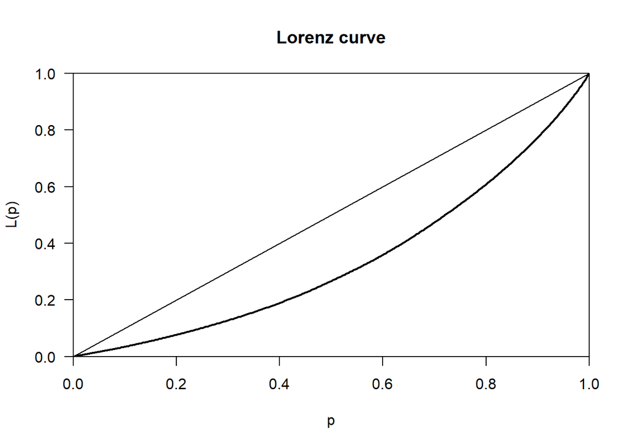

```r
plot(Lc(train$weight))
```

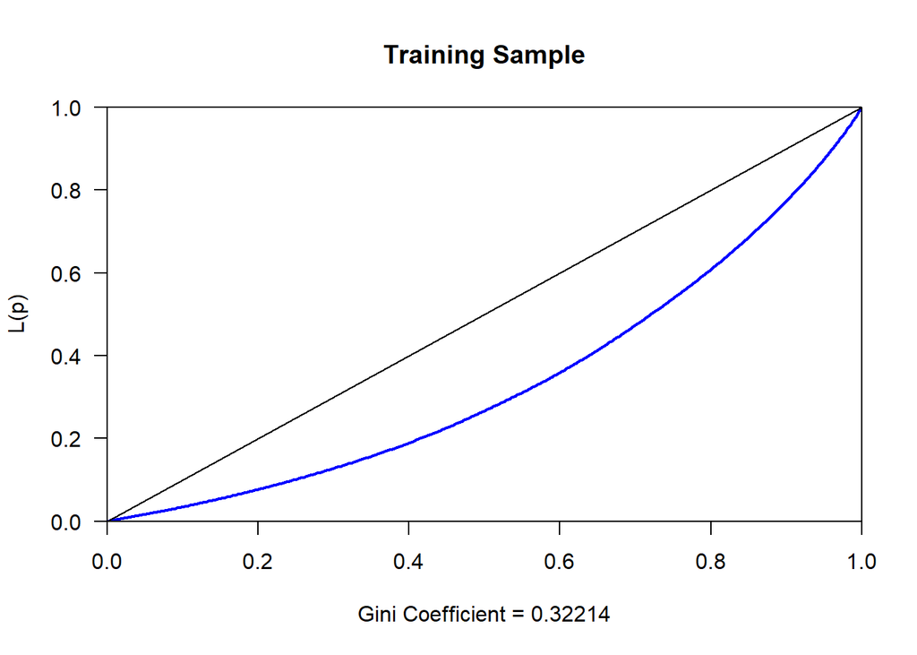

```r
#formatted output:
xtitle <- paste("Gini Coefficient =", round(gini(train$weight),5))
plot(Lc(train$weight), col = "blue", lwd = 2,
 main = "Training Sample", xlab = xtitle)
```

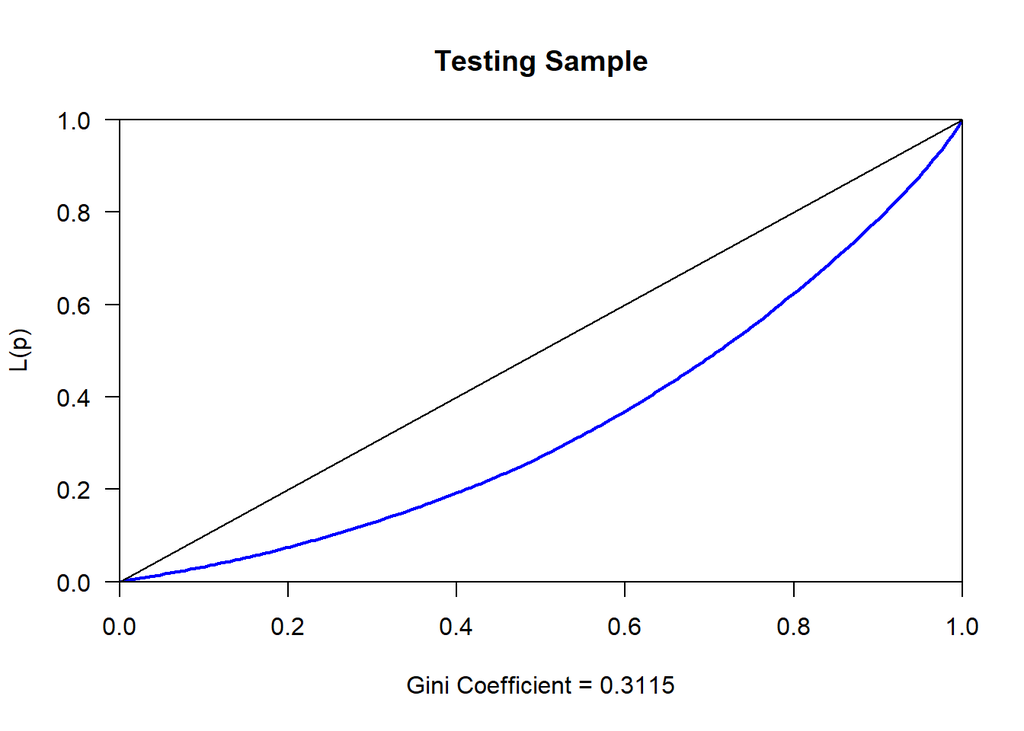

```r
# round(with(train, WeightedGini(weight, count, weight)), 5) # email sent to CAS. no WeightedGini function


test = chick_weight %>% filter(sample == "Test")

xtitle <- paste("Gini Coefficient =", round(gini(test$weight),5))
plot(Lc(test$weight), col = "blue", lwd = 2,
 main = "Testing Sample", xlab = xtitle)
```

```r
#Lc() sorts on actuals. LorenzCurve2() below sorts on predicted
```

https://www.kaggle.com/c/liberty-mutual-fire-peril/discussion/9880 http://blog.nguyenvq.com/blog/2015/09/25/calculate-the-weighted-gini-coefficient-or-auc-in-r/

```r
WeightedGini = function(actual,weights,predicted){
   # Modification of study note on validation for icas exam which was modified from post in Kaggle by William Cukierski
 # https://www.kaggle.com/c/liberty-mutual-fire-peril/discussion/9880
 # actual = actual frequency, severity, loss cost
 # corresponding weights = exposure, claim count, exposure
 # predicted = predicted
  set.seed(456)
  temp = data.frame(actual = actual, weights = weights, predicted = predicted)
  temp = temp %>%
    mutate(random_key = runif(nrow(temp))) %>%  # create random number sort key so ties will be resolved in random order. if data sorted by actuals before this and didn't sort by random gini could be overstated
    arrange(predicted,random_key) %>%
    mutate(random = cumsum(weights/sum(weights)),
           cumPosFound = cumsum(actual*weights),
           Lorentz = cumPosFound / max(cumPosFound))
  gini = sum(temp$Lorentz[-1]*temp$random[-nrow(temp)]) - sum(temp$Lorentz[-nrow(temp)] * temp$random[-1])
  return(gini)
}
```

```r
# Lorenz Curve function that uses predicted values for sorting. Lc() sorts on actuals
LorenzCurve2 <- function (x, n = rep(1, length(x)), xhat, plot = FALSE)
{
 # Modification of Lc function in ineq package
 # x = actual (frequency, severity, loss cost)
 # xhat = predicted (frequency, severity, loss cost)
 # n = weights (exposure, claims, exposure)
 # data will be sorted in ascending order of prediction
 # Lorenz Curve will be plotted based on actual values
 ina <- !is.na(x)
 n <- n[ina]
 x <- as.numeric(x)[ina]
 xhat <- as.numeric(xhat)[ina]
 k <- length(x)
 # create random number sort key so ties will be resolved in random order
 #rkey <- runif(k)
 #o <- order(xhat, rkey)
 o <- order(xhat)
 x <- x[o]
 n <- n[o]
 x <- n * x
 p <- cumsum(n)/sum(n)
 L <- cumsum(x)/sum(x)
 p <- c(0, p)
 L <- c(0, L)
 L2 <- L * mean(x)/mean(n)
 Lc <- list(p, L, L2)
 names(Lc) <- c("p", "L", "L.general")
 class(Lc) <- "Lc"
 if (plot)
 plot(Lc)
 Lc
}



#debugonce(LorenzCurve2)
# with(train_augment, plot(LorenzCurve2(weight, count, weight_pred),
#  col="blue", lwd=2,
#  main="Training Sample", xlab=xtitle))
```

```r
LorenzCurve_DC <- function (data = NULL, actual = NULL, weights = NULL, predicted = NULL, plot = FALSE)
{
 # Modification of Lc function in ineq package
 # actual = x = actual (frequency, severity, loss cost)
 # weights = n = weights (exposure, claims, exposure)
 # predicted = xhat = predicted (frequency, severity, loss cost)

 # data will be sorted in ascending order of prediction
 # Lorenz Curve will be plotted based on actual values

  #add a check if actual and predicted are numeric

 data = data %>%
   filter(!is.na(actual)) %>%
   arrange_(predicted) %>%
   mutate(totalPositive = actual * weights)


 return(data)
}

#debugonce(LorenzCurve_DC)
# LorenzCurve_DC(data = train_augment, actual = "weight", weights = "count", predicted = "weight_pred")

#  actual = "weight"
#  weights = "count"
#  predicted = "weight_pred"
# train_augment %>%
#   filter(!is.na(actual)) %>%
#    arrange_(predicted)
```

```r
round(with(train, WeightedGini(actual = weight,
                               weights = count,
                               predicted = weight)), 5)
```

```
## [1] 0.32214
```

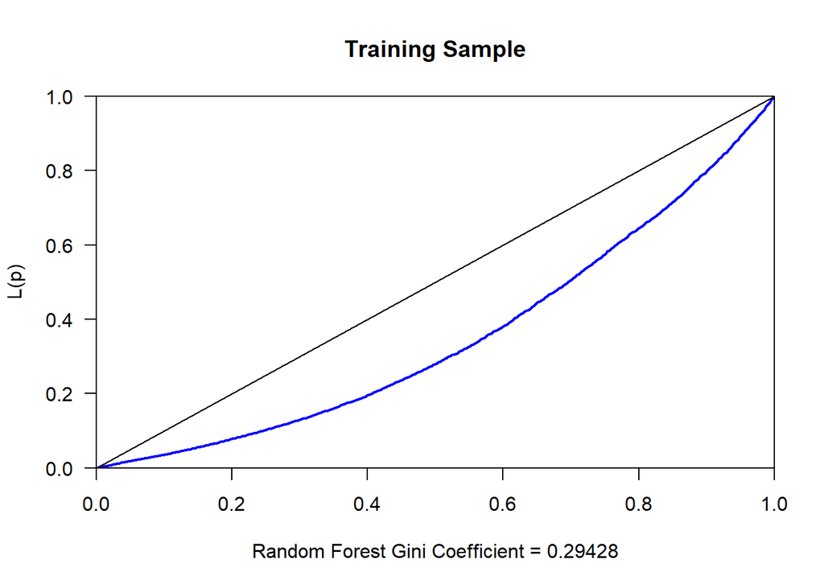

```r
pacman::p_load(randomForest)

set.seed(456)
model_rf = randomForest(weight ~ Diet + Time, data = train)

train_augment = train %>%
  mutate(weight_pred = predict(model_rf, train))


train_pgin = round(with(train_augment, WeightedGini(weight, count, weight_pred)), 5)


xtitle = paste("Random Forest Gini Coefficient =",
 round(train_pgin,5))

#debugonce(LorenzCurve2)
with(train_augment, plot(LorenzCurve2(weight, count, weight_pred),
 col="blue", lwd=2,
 main="Training Sample", xlab=xtitle))
```

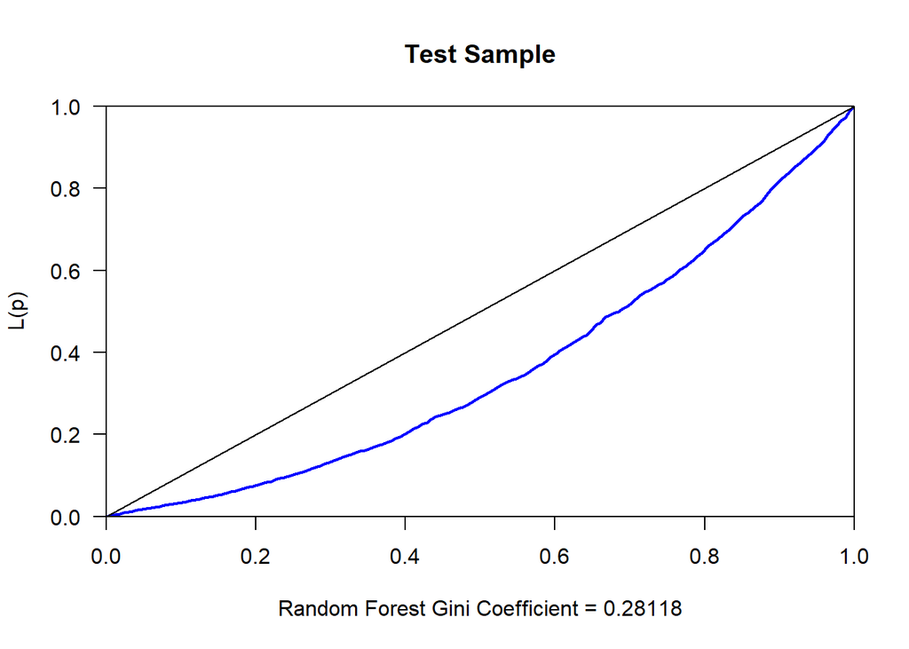

```r
# slightly different gini than the paper. train % same as source code. newer version of random forest?


# Predicted on Test Sample
test_augment = test %>%
  mutate(weight_pred = predict(model_rf, test))

test_pgin <- round(with(test_augment,WeightedGini(weight, count, weight_pred)), 5)

xtitle <- paste("Random Forest Gini Coefficient =",
 round(test_pgin,5))

with(test_augment, plot(LorenzCurve2(weight, count, weight_pred),
 col="blue", lwd=2,
 main="Test Sample", xlab=xtitle))
```

```r
norm_gini_train = round(train_pgin/gini(train$weight),5)
norm_gini_test = round(test_pgin,5)/round(gini(test$weight),5)
message('Normalized Gini on training sample = ',round(train_pgin,5),"/",round(gini(train$weight),5)," = ",norm_gini_train)
```

```
## Normalized Gini on training sample = 0.29428/0.32214 = 0.91351
```

```r
message('Normalized Gini on testing sample = ',round(test_pgin,5),"/",round(gini(test$weight),5)," = ",norm_gini_test)
```

```
## Normalized Gini on testing sample = 0.28118/0.3115 = 0.902664526484751
```

```r
message('Difference in normalized Gini = ',norm_gini_train - norm_gini_test) #or cat() but then need to insert page breaks
```

```
## Difference in normalized Gini = 0.0108454735152489
```

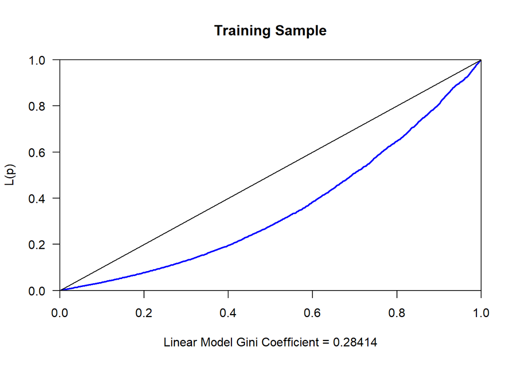

```r
#
# Fit linear regression training data
#

model_ols = lm(weight ~ Time,
 data = train)
# Predicted on Training Sample

train_augment = train %>%
  mutate(weight_pred = predict(model_ols, train))

set.seed(456)
train_pgin <- round(with(train_augment,
 WeightedGini(actual = weight, weights = count, predicted = weight_pred)), 5)

xtitle <- paste("Linear Model Gini Coefficient =",
 round(train_pgin,5))

with(train_augment, plot(LorenzCurve2(weight, count, weight_pred),
 col="blue", lwd=2,
main="Training Sample", xlab=xtitle))
```

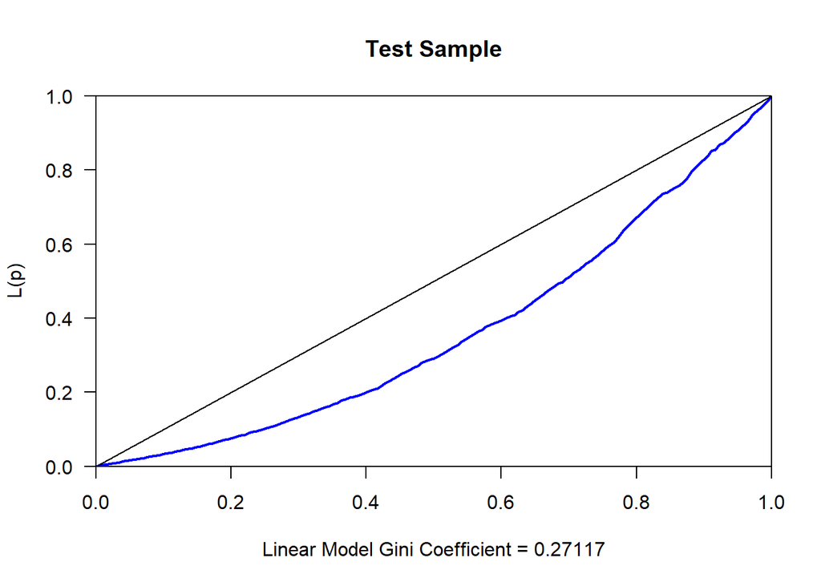

```r
# Predicted on Test Sample
test_augment = test %>%
  mutate(weight_pred = predict(model_ols, test))

test_pgin <- round(with(test_augment,
 WeightedGini(actual = weight, weights = count, predicted = weight_pred)), 5)


xtitle <- paste("Linear Model Gini Coefficient =",
 round(test_pgin,5))
with(test_augment, plot(LorenzCurve2(weight, count, weight_pred),
 col="blue", lwd=2,
 main="Test Sample", xlab=xtitle))
```

```r
norm_gini_train = round(train_pgin/gini(train$weight),5)
norm_gini_test = round(test_pgin/gini(test$weight),5)
message('Normalized Gini on training sample = ',round(train_pgin,5),"/",round(gini(train$weight),5)," = ",norm_gini_train)
```

```
## Normalized Gini on training sample = 0.28414/0.32214 = 0.88203
```

```r
message('Normalized Gini on testing sample = ',round(test_pgin,5),"/",round(gini(test$weight),5)," = ",norm_gini_test)
```

```
## Normalized Gini on testing sample = 0.27117/0.3115 = 0.87053
```

```r
message('Difference in normalized Gini = ',norm_gini_train - norm_gini_test) #or cat() but then need to insert page breaks
```

```
## Difference in normalized Gini = 0.0115
```

```r
# per ?gini() weights were originally created if it's a sample and you are inputting the mean income. weights would be number of people in that group.
```

LIFT CHARTS to compare two or more models

car.csv info from http://www.businessandeconomics.mq.edu.au/our_departments/Applied_Finance_and_Actuarial_Studies/research/books/GLMsforInsuranceData/data_sets This data set is based on one-year vehicle insurance policies taken out in 2004 or 2005. There are 67856 policies, of which 4624 (6.8%) had at least one claim.

Variables:

veh_value vehicle value, in $10,000s exposure 0-1 clm occurrence of claim (0 = no, 1 = yes) numclaims number of claims claimcst0 claim amount (0 if no claim) veh_body vehicle body, coded as BUS CONVT = convertible  
COUPE  
HBACK = hatchback  
HDTOP = hardtop MCARA = motorized caravan MIBUS = minibus PANVN = panel van RDSTR = roadster SEDAN  
STNWG = station wagon TRUCK  
UTE - utility veh_age age of vehicle: 1 (youngest), 2, 3, 4 gender gender of driver: M, F area driver’s area of residence: A, B, C, D, E, F agecat driver’s age category: 1 (youngest), 2, 3, 4, 5, 6

```r
#rewriting page 13 of study note on validation
car = read.csv("data/car.csv") #from http://www.businessandeconomics.mq.edu.au/our_departments/Applied_Finance_and_Actuarial_Studies/research/books/GLMsforInsuranceData/data_sets
car = car %>%
  rename(vehicle_value = veh_value,
         claim_ind = clm,
         claim_cost = claimcst0,
         vehicle_body = veh_body,
         vehicle_age = veh_age,
         age_cat = agecat) %>%
  mutate(vehicle_value = vehicle_value*10000,
         vehicle_age = as.factor(vehicle_age),#why didn't they leave this as a number?
         age_cat = as.factor(age_cat)) %>%
  select(-X_OBSTAT_) %>%
  filter(claim_cost > 0) #since we're fitting a severity model

set.seed(189763)
car_total = car %>%
  mutate(random = runif(nrow(car)),
         split = if_else(random < .6 ,"train","holdout")) #runif is Random number from UNIForm distribution

car_train = car_total  %>% filter(split == "train")
car_holdout = car_total %>% filter(split == "holdout")
rm(car)
```

```r
model_1 = glm(claim_cost ~ area + vehicle_age,
               data = car_train,
               family = Gamma(link = "log"))

model_2 = glm(claim_cost ~ area + vehicle_age + gender,
               data = car_train,
               family = Gamma(link = "log"))

car_augment = car_holdout %>%
  mutate(model_1_pred = predict(model_1,newdata = car_holdout,type = "response")) %>%
  mutate(model_2_pred = predict(model_2,newdata = car_holdout,type = "response"))

car_augment
```

```
##      vehicle_value    exposure claim_ind numclaims claim_cost vehicle_body
## 1             7600 0.539356605         1         1   401.8055        HBACK
## 2            13900 0.317590691         1         1   865.7900        HBACK
## 3             5000 0.071184121         1         1   200.0000        HBACK
## 4            15400 0.616016427         1         1   200.0000        STNWG
## 5            44600 0.191649555         1         1   989.9200        COUPE
## 6            14400 0.665297741         1         1   500.0000          UTE
## 7            30000 0.613278576         1         1  6372.0300        STNWG
## 8            12900 0.925393566         1         1   200.0000        SEDAN
## 9            11300 0.377823409         1         1   937.5600        SEDAN
## 10           24100 0.750171116         1         1 12879.6600        HBACK
## 11           31400 0.851471595         1         2 19142.1327        TRUCK
## 12            6200 0.908966461         1         1   367.7300        STNWG
## 13           26400 0.525667351         1         1   462.7000          UTE
## 14           17490 0.413415469         1         1 13589.7899        HBACK
```

[output cut: 5391 more lines]

```r
set.seed(13472)
car_augment_bins = car_augment %>%
  mutate(random = runif(nrow(car_holdout))) %>%
  arrange(model_2_pred,random) %>%
  mutate(exposure_cumsum = cumsum(exposure)) %>%
  arrange(model_2_pred) #not needed but to check that ntile worked



car_augment_bins = car_augment_bins %>%
  mutate(bin_model_2_pred = cut(exposure_cumsum,breaks = c(0,1:9*sum(car_augment_bins$exposure)/10,sum(car_augment_bins$exposure)*1.1)))

#check bins worked
car_augment_bins %>%
  group_by(bin_model_2_pred) %>%
  summarize(total_exposure = sum(exposure),
            model_2_pred_min = min(model_2_pred),
            model_2_pred_max = max(model_2_pred),
            rows = n()) #matches line 53 tapply() exactly
```

```
## # A tibble: 10 x 5
##    bin_model_2_pred total_exposure model_2_pred_min model_2_pred_max  rows
##    <fct>                     <dbl>            <dbl>            <dbl> <int>
##  1 (0,110]                    110.            1493.            1660.   177
##  2 (110,221]                  110.            1660.            1714.   175
##  3 (221,331]                  111.            1714.            1831.   178
##  4 (331,442]                  110.            1831.            1955.   175
##  5 (442,552]                  110.            1955.            1988.   185
##  6 (552,663]                  110.            1988.            2154.   183
##  7 (663,773]                  110.            2154.            2258.   182
##  8 (773,883]                  111.            2258.            2472.   182
##  9 (883,994]                  110.            2472.            2513.   177
## 10 (994,1.21e+03]             111.            2513.            3645.   187
```

```r
car_augment_bins
```

```
##      vehicle_value    exposure claim_ind numclaims claim_cost vehicle_body
## 1            18490 0.681724846         1         1   436.4700        SEDAN
## 2            39000 0.736481862         1         1   353.7700          UTE
## 3            13500 0.339493498         1         1   200.0000        HBACK
## 4            36400 0.536618754         1         1   200.0000        STNWG
## 5            13100 0.334017796         1         1   200.0000        HBACK
## 6            19600 0.673511294         1         1   928.4500        HBACK
## 7            12400 0.347707050         1         1   710.3500        HBACK
## 8            27500 0.446269678         1         1   657.8000        SEDAN
## 9            14800 0.985626283         1         1   480.0000        HBACK
## 10           25500 0.856947296         1         1  1065.5300        SEDAN
## 11           25900 0.991101985         1         1   353.7700        SEDAN
## 12           30000 0.750171116         1         1   698.6400        STNWG
## 13           37800 0.815879535         1         1   200.0000        STNWG
## 14           34900 0.999315537         1         1  2243.0400          UTE
```

[output cut: 5391 more lines]